# Exploratory Image Analysis

Here we explore basic statistics and class characteristics of the dataset to evaluate it quantitatively and qualitatively.

We examine visual features that YOLOv8 relies on at low-level (edges, textures, color), mid-level (object parts such as beards and hats), and high-level (humanoid structure and red–white gestalt). This helps us identify potential biases and confusion sources, particularly with Santa-like hard negatives (e.g. the Grinch).

Guidelines for the project

- data inspection: how many samples, classes, labels, class imbalances
- object classes, distributions, statistics, imbalanes, bias ... consider when training, weighted loss
- qualitative and quantitative sense of data
- dicuss dataset challenges and how to overcome them
- visualize image labels and bounding boxes

## Connect to Gdrive and load the Roboflow dataset

```python
from google.colab import drive
drive.flush_and_unmount()
drive.mount('/content/drive/', force_remount=True)

%cd /content/drive/My Drive/FHNW/HS_25/DLBS/minichallenge_hs25_object_detection/MC
```

```
Drive not mounted, so nothing to flush and unmount.
/content/drive/My Drive/FHNW/HS_25/DLBS/minichallenge_hs25_object_detection/MC
```

```python
from helpers import (
    load_roboflow_data,
    analyze_dataset,
    get_yolo_stats,
    plot_spatial_heatmap,
    visualize_images,
    analyze_split,
    plot_object_distribution,
    plot_color_histogram
)
```

```python
from google.colab import userdata
api_key = userdata.get('ROBOFLOW_API_KEY')

!pip install roboflow
from roboflow import Roboflow
rf = Roboflow(api_key=api_key)
project = rf.workspace('dlbs-xi5zk').project('santa-qqpxm')
version = project.version(10)
dataset = version.download('yolov8')
```

```
loading Roboflow workspace...
loading Roboflow project...
```

## Dataset directory content

```python
analyze_dataset(dataset.location);
```

```
🔎 Total: 950 | Train: 700 (73.7%) | Valid: 155 (16.3%) | Test: 95 (10.0%)
📋 Classes: ['Santa'] | NC: 1
```

```python
import os
DATASET_PATH = './Santa-10'
splits = ["train", "valid", "test"]
for split in splits:
  image_dir = os.path.join(DATASET_PATH, split, "images")
  extensions = set(f.split('.')[-1].lower() for f in os.listdir(image_dir))
  print(split, extensions)
```

```
train {'jpg'}
valid {'jpg'}
test {'jpg'}
```

```python
# confirm the images and labels folders exist
!ls -F Santa-10/train/
```

```
images/  labels/
```

```python
# Check images
!ls -F Santa-10/test/images | head -n 5
```

```
0-38862400_1671944344_santa_jpg.rf.55c6e9ce609b22e4451a311482828cd1.jpg
102_Santa_jpg.rf.8f184416dd01520cdc916a754e3001e6.jpg
146_Santa_jpg.rf.194951c92edbafce3d8144c398a907f5.jpg
156_Santa_jpg.rf.6ae01fa7adaefdd768712c55de29f1d5.jpg
174_Santa_jpg.rf.95ae299d0f0ef1d76006a4863c8e4b3e.jpg
```

```python
# Check their annotations - same name, but the file ending is .txt
!ls -F Santa-10/test/labels/ | head -n 5
```

```
0-38862400_1671944344_santa_jpg.rf.55c6e9ce609b22e4451a311482828cd1.txt
102_Santa_jpg.rf.8f184416dd01520cdc916a754e3001e6.txt
146_Santa_jpg.rf.194951c92edbafce3d8144c398a907f5.txt
156_Santa_jpg.rf.6ae01fa7adaefdd768712c55de29f1d5.txt
174_Santa_jpg.rf.95ae299d0f0ef1d76006a4863c8e4b3e.txt
```

## Dataset visual inspection and statistics

```python
import cv2
import glob
import random

for split in splits:
    search_path = os.path.join(DATASET_PATH, split, "images", "*.jpg")
    all_image_paths = glob.glob(search_path)

    # If no JPGs were found, try PNGs
    if not all_image_paths:
        search_path_png = os.path.join(DATASET_PATH, split, "images", "*.png")
        all_image_paths = glob.glob(search_path_png)

    print(f"\nFound {len(all_image_paths)} total images in the {split} split.")

    visualize_images(all_image_paths, split.capitalize())
```

```
Output hidden; open in https://colab.research.google.com to view.
```

Santas appear on different backgrounds, which reduces the risk of the model relying on spurious correlations. Some images contain men or figures that visually resemble Santa (beards, red clothing, similar build), which is valuable for teaching the model to discriminate true Santa instances from lookalikes. The dataset includes photographs, paintings, and cartoons. This variation helps the model generalize beyond a single image type. The bounding boxes are accurately placed and the associated class labels (Santa) is correct.

## YOLO stats

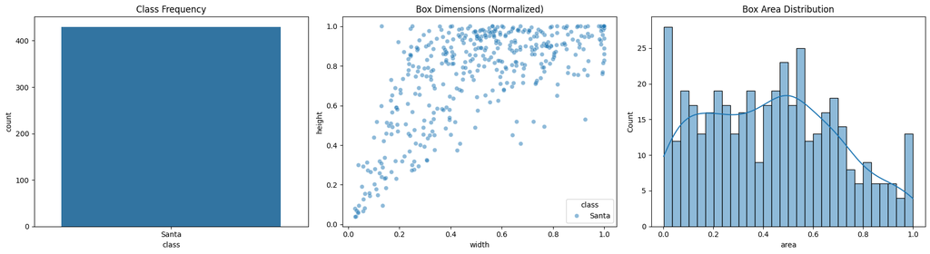

```python
import matplotlib.pyplot as plt
import seaborn as sns

LABEL_DIR = './Santa-10/train/labels'
CLASSES = ['Santa']

df = get_yolo_stats(LABEL_DIR, CLASSES)

# Plotting
fig, axes = plt.subplots(1, 3, figsize=(18, 5))

# 1. Class Distribution
sns.countplot(data=df, x='class', ax=axes[0])
axes[0].set_title('Class Frequency')

# 2. Aspect Ratio (Width vs Height)
sns.scatterplot(data=df, x='width', y='height', hue='class', alpha=0.5, ax=axes[1])
axes[1].set_title('Box Dimensions (Normalized)')

# 3. Area Distribution
sns.histplot(df['area'], bins=30, kde=True, ax=axes[2])
axes[2].set_title('Box Area Distribution')

plt.tight_layout()
plt.show()
```

We have one single 'Santa' class with over 400 instances.

This scatter plot shows the width vs. height of every bounding box, normalized from 0 to 1. We have diverse bounding box sizes, from very small to nearly full-image objects, which is great for training the model to detect Santas at different scales.

Large objects: Many Santas are relatively large, which is good for ensuring the model can detect those.

Some small bounding boxes will need extra attention. If we want the model to detect Santas that are far away (small boxes), we need to use data augmentation (scaling).

The last histogram shows the total area (W×H) each box covers. The distribution is relatively uniform, with a slight peak around 0.5 (half the image) and a sharp spike at the very low end (near 0.0). We see a cluster of very small objects. YOLO might struggle with these if the resolution (640×640) is not high enough to capture the details.  
The fact that boxes range from 0% to 100% of the image area is good. It means our model is being trained to recognize the object at multiple scales, which makes it more robust.

## Number of objects per image

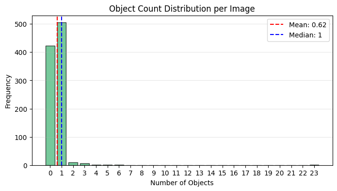

```
📦 STATISTICS:
Mean: 0.62 | Median: 1 | Max: 23
Background (0 objs): 423
Single Object: 505
Multiple Objects: 22
```

```python
plot_object_distribution(DATASET_PATH);
```

Since about 44% of the dataset consists of background images (0 objects), the model is being heavily trained on what "not-Santa" looks like. Because your mean is 0.62, the model will spend more time learning that a cell is "empty" than "full." In one case of Santa run we have 23 Santas, but YOLOv8 handles crowded scenes well.

## Annotation heatmap

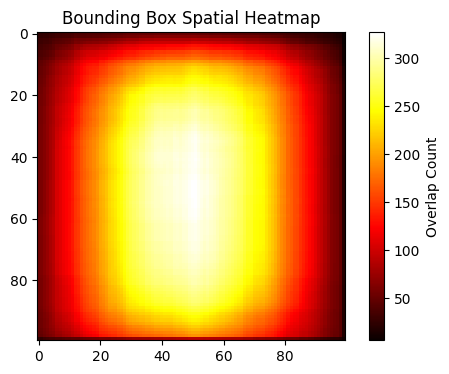

```python
plot_spatial_heatmap(df, res=100)
```

Shows where most of the annotations are. Color gradients signify the number of annotations per grid cell. Our dataset has a strong center bias. Almost every "Santa" is located in the middle of the frame.

We may want to use Translation or Random Crop augmentations during training to ensure the model can detect Santas that appear near the edges or corners of an image.

## Distribution of labels

```python
analyze_split(DATASET_PATH)
```

```
============================================================
📊 TRAIN SPLIT ANALYSIS
============================================================
Total images: 700
Total Santa objects (positive examples): 430
Images containing Santa: 373
Images without Santa: 327
Images with >1 bounding box: 20
Percentage of images with Santa: 53.29%
Percentage of background-only images: 46.71%
Average Santa per image (with Santa): 1.15

============================================================
📊 VALID SPLIT ANALYSIS
============================================================
Total images: 155
Total Santa objects (positive examples): 105
Images containing Santa: 101
Images without Santa: 54
Images with >1 bounding box: 2
Percentage of images with Santa: 65.16%
Percentage of background-only images: 34.84%
Average Santa per image (with Santa): 1.04

============================================================
📊 TEST SPLIT ANALYSIS
============================================================
Total images: 95
Total Santa objects (positive examples): 53
Images containing Santa: 53
Images without Santa: 42
Images with >1 bounding box: 0
Percentage of images with Santa: 55.79%
Percentage of background-only images: 44.21%
Average Santa per image (with Santa): 1.00
```

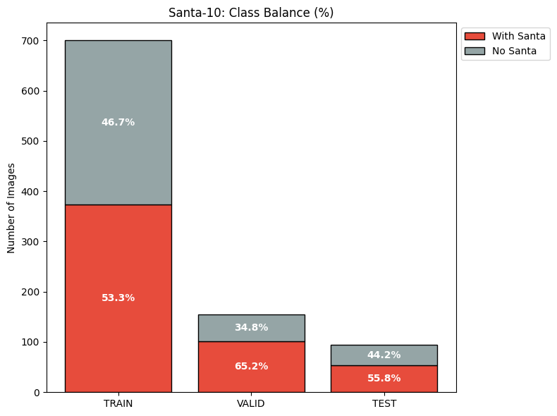

```python
import os, glob, numpy as np, matplotlib.pyplot as plt

splits = ['train', 'valid', 'test']
results = {}

# 1. Concise Analysis
for s in splits:
    imgs = glob.glob(f'{DATASET_PATH}/{s}/images/*.[jp][pn]g')
    has_obj = sum(1 for img in imgs if os.path.exists(img.replace('/images/', '/labels/').rsplit('.', 1)[0] + '.txt') and any(open(img.replace('/images/', '/labels/').rsplit('.', 1)[0] + '.txt').read().strip()))
    results[s] = (has_obj, len(imgs) - has_obj, len(imgs))

# 2. Plotting (Percentages Only)
fig, ax = plt.subplots(figsize=(8, 6))
x = np.arange(len(splits))
vals = np.array([results[s] for s in splits])

ax.bar(x, vals[:,0], label='With Santa', color='#e74c3c', edgecolor='black')
ax.bar(x, vals[:,1], bottom=vals[:,0], label='No Santa', color='#95a5a6', edgecolor='black')

for i, (w, wo, t) in enumerate(vals):
    # Centered percentage for "With Santa"
    if w > 0:
        ax.text(i, w/2, f'{w/t*100:.1f}%', ha='center', va='center', color='white', weight='bold')
    # Centered percentage for "No Santa"
    if wo > 0:
        ax.text(i, w + wo/2, f'{wo/t*100:.1f}%', ha='center', va='center', color='white', weight='bold')

ax.set(xticks=x, xticklabels=[s.upper() for s in splits], ylabel='Number of Images', title='Santa-10: Class Balance (%)')
ax.legend(bbox_to_anchor=(1, 1), loc='upper left')
plt.tight_layout()
plt.show()
```

All splits maintain a high ratio of background-only images (34.8% – 46.7%), which is critical for minimizing False Positives during inference. The validation split contains a higher density of positive samples (65.2%) compared to train (53.3%), so the validation mAP may appear slightly optimistic due to this higher frequency of Santa images relative to the training distribution.

However, since the primary objective is to assess the model's performance on detecting "Santa" in the presence of a large background, this setup ensures that the model's ability to identify the target class is properly emphasized.

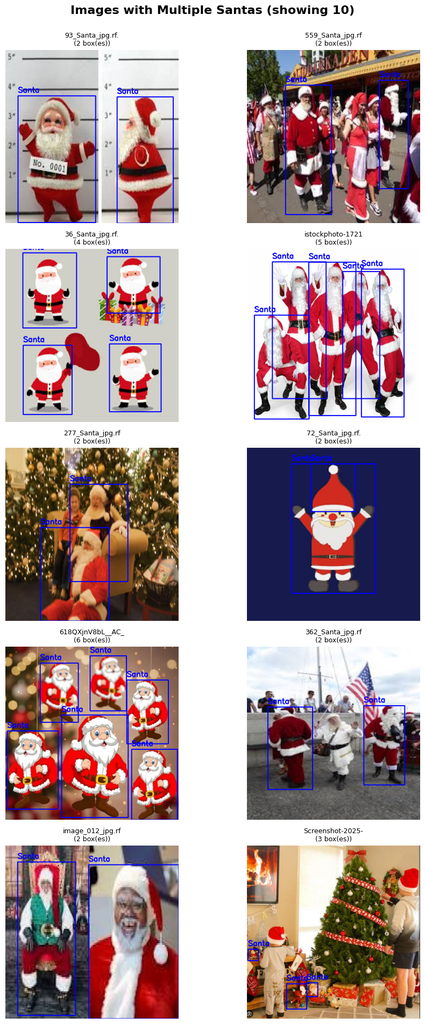

```python
# 1. Configuration & Path Setup
PATH = './Santa-10/train' # Adjust to your specific split
img_paths = sorted(glob.glob(f'{PATH}/images/*.jpg'))
lbl_paths = [p.replace('/images/', '/labels/').rsplit('.', 1)[0] + '.txt' for p in img_paths]

# 2. Filter for Multiple Bounding Boxes
multi_bbox_data = []
for img_p, lbl_p in zip(img_paths, lbl_paths):
    if os.path.exists(lbl_p):
        with open(lbl_p, 'r') as f:
            lines = [l.strip() for l in f if l.strip()]
            if len(lines) > 1:
                multi_bbox_data.append((img_p, lines))

# 3. Visualization
sample_size = min(10, len(multi_bbox_data))
indices = np.random.choice(len(multi_bbox_data), sample_size, replace=False)

fig, axes = plt.subplots(5, 2, figsize=(10, 20))
fig.suptitle(f"Images with Multiple Santas (showing {sample_size})", fontsize=16, fontweight='bold')

for i, idx in enumerate(indices):
    img_p, lines = multi_bbox_data[idx]
    img = cv2.imread(img_p)
    img = cv2.cvtColor(img, cv2.COLOR_BGR2RGB)
    h_img, w_img, _ = img.shape

    for line in lines:
        cls, x, y, w, h = map(float, line.split())
        # Convert YOLO normalized to Pixel coordinates
        x1 = int((x - w/2) * w_img)
        y1 = int((y - h/2) * h_img)
        x2 = int((x + w/2) * w_img)
        y2 = int((y + h/2) * h_img)

        # Draw Rectangle
        cv2.rectangle(img, (x1, y1), (x2, y2), (0, 0, 255), 2)
        cv2.putText(img, f'Santa', (x1, y1-10),
                   cv2.FONT_HERSHEY_SIMPLEX, 0.7, (0, 0, 255), 2)

    ax = axes[i//2, i%2]
    ax.imshow(img)
    ax.set_title(f"{os.path.basename(img_p[:40])}\n({len(lines)} box(es))", fontsize=9)
    ax.axis('off')

plt.tight_layout(rect=[0, 0.03, 1, 0.98])
plt.show()
```

Most of our positive examples are single-target images, which is great for a baseline detector, but the model might initially struggle to detect overlapping Santas.

### Image characteristics: edges & color scheme

When combined, edges and color form a powerful set of visual features for object detection. They help minimize false positives and detect Santa in an image even if the background changes.

[output not shown]

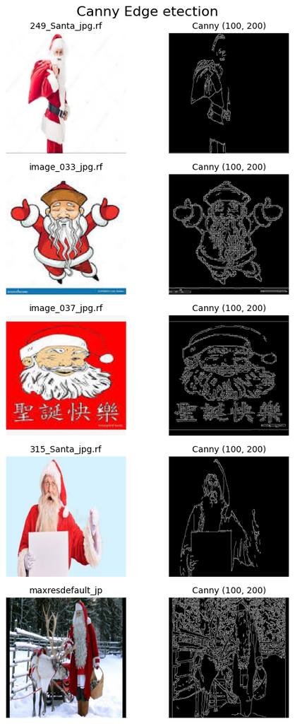

```python
# Find all images and filter for Santa-only
IMAGE_EXT = '*.jpg'
TARGET_CLASS = 0

all_train_images = glob.glob(os.path.join(PATH, 'images', IMAGE_EXT))
santa_images = []

for img_path in all_train_images:
    label_path = img_path.replace('images', 'labels').rsplit('.', 1)[0] + '.txt'

    if os.path.exists(label_path):
        with open(label_path, 'r') as f:
            labels = [int(line.split()[0]) for line in f.readlines()]

            if labels and all(label == TARGET_CLASS for label in labels):
                santa_images.append(img_path)

print(f"Found {len(santa_images)} images containing only Santa class.\n")

# Select 5 random images and apply Canny edge detection
sample_images = random.sample(santa_images, 5)

# Create figure with 2 columns (original, Canny)
fig, axes = plt.subplots(5, 2, figsize=(6,12))
fig.suptitle('Canny Edge Detection', fontsize=16)

for row, img_path in enumerate(sample_images):
    img = cv2.imread(img_path)
    img_rgb = cv2.cvtColor(img, cv2.COLOR_BGR2RGB)

    edges = cv2.Canny(img, 100, 200)

    # Original
    axes[row, 0].imshow(img_rgb)
    axes[row, 0].set_title(f'{os.path.basename(img_path[:40])}', fontsize=10)
    axes[row, 0].axis('off')

    # Canny
    axes[row, 1].imshow(edges, cmap='gray')
    axes[row, 1].set_title(f'Canny (100, 200)', fontsize=10)
    axes[row, 1].axis('off')

plt.tight_layout()
plt.show()
```

Edges help in defining the shape of objects. The transitions in pixel intensity from dark to light create a clear outline, which is essential for identifying where an object starts and ends.

Consistent Features: Hat edges are distinct across all images, body contours are visible, face features (beard) show up consistently. Most outlines are very clear.

If objects have blurry, poor edges we can expect potential training issues, while high-contrast objectswith strong edges are easier for model to learn. Lots of background edge details and incomplete edges on illustrated Santas could also be problematic.

```python
for split in ['train', 'valid', 'test']:
    paths = glob.glob(f'{DATASET_PATH}/{split}/images/*.[jp][pn]g')
    if paths:
        print(f"\n{split.upper()}: {len(paths)} images")
        plot_color_histogram(paths, split.capitalize())
```

```
Output hidden; open in https://colab.research.google.com to view.
```

The model can learn color patterns to distinguish between objects that look visually similar but are different (Santa vs. Grinch). The color distribution might also trick the model to misclassify another person in red clothing for Santa, if other features are confusing.

Several histograms show strong peaks in the RED channel. Since red is a primary feature of Santa's suit, the model will likely develop high-sensitivity filters for the Red channel.

With reds being of different value, the model can be trained to recognize various lighting conditions and color variations (e.g., dark red vs. bright red) to improve its ability to generalize across different scenarios.

Would we benefit from training on grayscale versions of these images and frocing YOLO to ignore the "red suit" shortcut and learn the actual geometry of a Santa figure?

```python
%pwd
```

```
'/content/drive/MyDrive/FHNW/HS_25/DLBS/minichallenge_hs25_object_detection/MC'
```

```python
!jupyter nbconvert --to html "/content/drive/MyDrive/FHNW/HS_25/DLBS/minichallenge_hs25_object_detection/MC/01_exploratory_image_analysis.ipynb"
```

```
[NbConvertApp] Converting notebook /content/drive/MyDrive/FHNW/HS_25/DLBS/minichallenge_hs25_object_detection/MC/01_exploratory_image_analysis.ipynb to html
[NbConvertApp] WARNING | Alternative text is missing on 6 image(s).
[NbConvertApp] Writing 3447164 bytes to /content/drive/MyDrive/FHNW/HS_25/DLBS/minichallenge_hs25_object_detection/MC/01_exploratory_image_analysis.html
```